# SCMA Exam I - Bharathwaj_Adarsh_V01107513

Adarsh Bharathwaj

2024-07-11

```r
## Current Working Directory of the project
getwd()
```

```
## [1] "C:/Users/Adarsh/Favorites/SCMA 2024/Exam I"
```

```r
## Loading the data
cancer <- read.csv("cancer_reg.csv")
cancer -> cancer1
```

## Function to auto-install and load packages

```r
install_and_load <- function(packages) {
  for (package in packages) {
    if (!require(package, character.only = TRUE)) {
      install.packages(package, dependencies = TRUE)
    }
    library(package, character.only = TRUE)
  }
}

# List of packages to install and load
packages <- c("nortest", "DataExplorer", "MASS", "lmtest", "car")

# Call the function
install_and_load(packages)
```

## Data Cleaning

```r
## Data Preparation and Understanding
summary(cancer1)
```

```
##   avgAnnCount      avgDeathsPerYear TARGET_deathRate incidenceRate
##  Min.   :    6.0   Min.   :    3    Min.   : 59.7    Min.   : 201.3
##  1st Qu.:   76.0   1st Qu.:   28    1st Qu.:161.2    1st Qu.: 420.3
##  Median :  171.0   Median :   61    Median :178.1    Median : 453.5
##  Mean   :  606.3   Mean   :  186    Mean   :178.7    Mean   : 448.3
##  3rd Qu.:  518.0   3rd Qu.:  149    3rd Qu.:195.2    3rd Qu.: 480.9
##  Max.   :38150.0   Max.   :14010    Max.   :362.8    Max.   :1206.9
##
##    medIncome        popEst2015       povertyPercent   studyPerCap
##  Min.   : 22640   Min.   :     827   Min.   : 3.20   Min.   :   0.00
##  1st Qu.: 38883   1st Qu.:   11684   1st Qu.:12.15   1st Qu.:   0.00
##  Median : 45207   Median :   26643   Median :15.90   Median :   0.00
##  Mean   : 47063   Mean   :  102637   Mean   :16.88   Mean   : 155.40
##  3rd Qu.: 52492   3rd Qu.:   68671   3rd Qu.:20.40   3rd Qu.:  83.65
##  Max.   :125635   Max.   :10170292   Max.   :47.40   Max.   :9762.31
##
##   binnedInc           MedianAge      MedianAgeMale   MedianAgeFemale
##  Length:3047        Min.   : 22.30   Min.   :22.40   Min.   :22.30
##  Class :character   1st Qu.: 37.70   1st Qu.:36.35   1st Qu.:39.10
##  Mode  :character   Median : 41.00   Median :39.60   Median :42.40
##                     Mean   : 45.27   Mean   :39.57   Mean   :42.15
##                     3rd Qu.: 44.00   3rd Qu.:42.50   3rd Qu.:45.30
##                     Max.   :624.00   Max.   :64.70   Max.   :65.70
##
##   Geography         AvgHouseholdSize PercentMarried   PctNoHS18_24
##  Length:3047        Min.   :0.0221   Min.   :23.10   Min.   : 0.00
##  Class :character   1st Qu.:2.3700   1st Qu.:47.75   1st Qu.:12.80
##  Mode  :character   Median :2.5000   Median :52.40   Median :17.10
##                     Mean   :2.4797   Mean   :51.77   Mean   :18.22
##                     3rd Qu.:2.6300   3rd Qu.:56.40   3rd Qu.:22.70
##                     Max.   :3.9700   Max.   :72.50   Max.   :64.10
##
##    PctHS18_24   PctSomeCol18_24 PctBachDeg18_24   PctHS25_Over
##  Min.   : 0.0   Min.   : 7.10   Min.   : 0.000   Min.   : 7.50
##  1st Qu.:29.2   1st Qu.:34.00   1st Qu.: 3.100   1st Qu.:30.40
##  Median :34.7   Median :40.40   Median : 5.400   Median :35.30
##  Mean   :35.0   Mean   :40.98   Mean   : 6.158   Mean   :34.80
##  3rd Qu.:40.7   3rd Qu.:46.40   3rd Qu.: 8.200   3rd Qu.:39.65
##  Max.   :72.5   Max.   :79.00   Max.   :51.800   Max.   :54.80
##                 NA's   :2285
```

[output cut: 17 more lines]

```
##  Min.   : 2.60          Min.   : 10.20   Min.   : 0.0000   Min.   : 0.0000
##  1st Qu.:14.85          1st Qu.: 77.30   1st Qu.: 0.6207   1st Qu.: 0.2542
##  Median :18.80          Median : 90.06   Median : 2.2476   Median : 0.5498
##  Mean   :19.24          Mean   : 83.65   Mean   : 9.1080   Mean   : 1.2540
##  3rd Qu.:23.10          3rd Qu.: 95.45   3rd Qu.:10.5097   3rd Qu.: 1.2210
##  Max.   :46.60          Max.   :100.00   Max.   :85.9478   Max.   :42.6194
##
##   PctOtherRace     PctMarriedHouseholds   BirthRate
##  Min.   : 0.0000   Min.   :22.99        Min.   : 0.000
##  1st Qu.: 0.2952   1st Qu.:47.76        1st Qu.: 4.521
##  Median : 0.8262   Median :51.67        Median : 5.381
##  Mean   : 1.9835   Mean   :51.24        Mean   : 5.640
##  3rd Qu.: 2.1780   3rd Qu.:55.40        3rd Qu.: 6.494
##  Max.   :41.9303   Max.   :78.08        Max.   :21.326
##
```

```r
names(cancer1)
```

```
##  [1] "avgAnnCount"             "avgDeathsPerYear"
##  [3] "TARGET_deathRate"        "incidenceRate"
##  [5] "medIncome"               "popEst2015"
##  [7] "povertyPercent"          "studyPerCap"
##  [9] "binnedInc"               "MedianAge"
## [11] "MedianAgeMale"           "MedianAgeFemale"
## [13] "Geography"               "AvgHouseholdSize"
## [15] "PercentMarried"          "PctNoHS18_24"
## [17] "PctHS18_24"              "PctSomeCol18_24"
## [19] "PctBachDeg18_24"         "PctHS25_Over"
## [21] "PctBachDeg25_Over"       "PctEmployed16_Over"
## [23] "PctUnemployed16_Over"    "PctPrivateCoverage"
## [25] "PctPrivateCoverageAlone" "PctEmpPrivCoverage"
## [27] "PctPublicCoverage"       "PctPublicCoverageAlone"
## [29] "PctWhite"                "PctBlack"
## [31] "PctAsian"                "PctOtherRace"
## [33] "PctMarriedHouseholds"    "BirthRate"
```

```r
head(cancer1)
```

```
##   avgAnnCount avgDeathsPerYear TARGET_deathRate incidenceRate medIncome
## 1        1397              469            164.9         489.8     61898
## 2         173               70            161.3         411.6     48127
## 3         102               50            174.7         349.7     49348
## 4         427              202            194.8         430.4     44243
## 5          57               26            144.4         350.1     49955
## 6         428              152            176.0         505.4     52313
##   popEst2015 povertyPercent studyPerCap          binnedInc MedianAge
## 1     260131           11.2   499.74820  (61494.5, 125635]      39.3
## 2      43269           18.6    23.11123 (48021.6, 51046.4]      33.0
## 3      21026           14.6    47.56016 (48021.6, 51046.4]      45.0
## 4      75882           17.1   342.63725   (42724.4, 45201]      42.8
## 5      10321           12.5     0.00000 (48021.6, 51046.4]      48.3
## 6      61023           15.6   180.25990 (51046.4, 54545.6]      45.4
##   MedianAgeMale MedianAgeFemale                    Geography AvgHouseholdSize
```

[output cut: 41 more lines]

```r
tail(cancer1)
```

```
##      avgAnnCount avgDeathsPerYear TARGET_deathRate incidenceRate medIncome
## 3042    1962.668               48            146.4      453.5494     49508
## 3043    1962.668               15            149.6      453.5494     46961
## 3044    1962.668               43            150.1      453.5494     48609
## 3045    1962.668               46            153.9      453.5494     51144
## 3046    1962.668               52            175.0      453.5494     50745
## 3047    1962.668               48            213.6      453.5494     41193
##      popEst2015 povertyPercent studyPerCap          binnedInc MedianAge
## 3042      29029           13.0    723.4145 (48021.6, 51046.4]      32.2
## 3043       6343           12.4      0.0000   (45201, 48021.6]      44.2
## 3044      37118           18.8    377.1755 (48021.6, 51046.4]      30.4
## 3045      34536           15.0   1968.9599 (51046.4, 54545.6]      30.9
## 3046      25609           13.3      0.0000 (48021.6, 51046.4]      39.0
## 3047      37030           13.9      0.0000 (40362.7, 42724.4]      26.2
##      MedianAgeMale MedianAgeFemale                Geography AvgHouseholdSize
```

[output cut: 41 more lines]

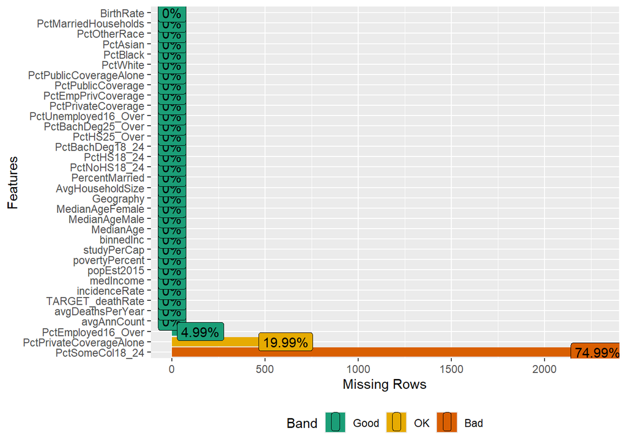

```r
## Using plots to understand the data
plot_str(cancer1)
plot_missing(cancer1)
```

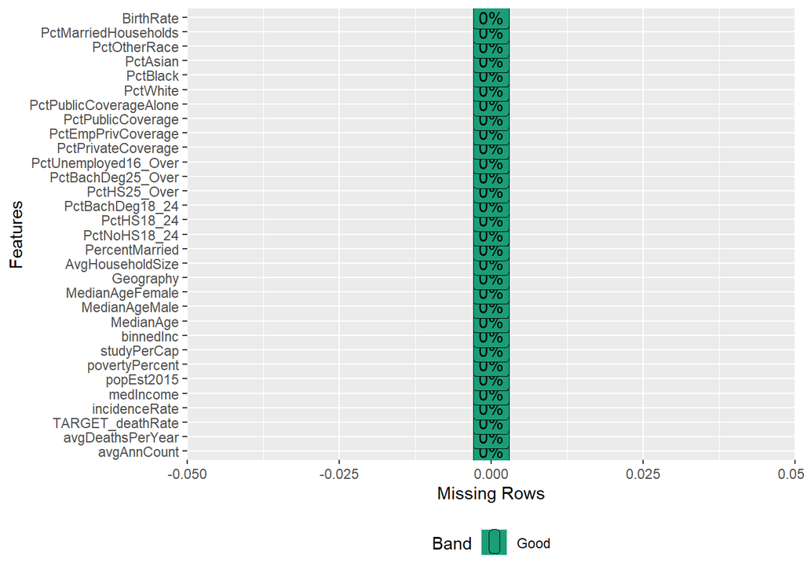

```r
# Identify columns with missing values
cols_with_na <- sapply(cancer1, function(x) any(is.na(x)))

# Remove columns with missing values
cancer1_cleaned <- cancer1[, !cols_with_na]

## Using plots to understand the data
plot_str(cancer1_cleaned)
plot_missing(cancer1_cleaned)
```

## Data Understanding

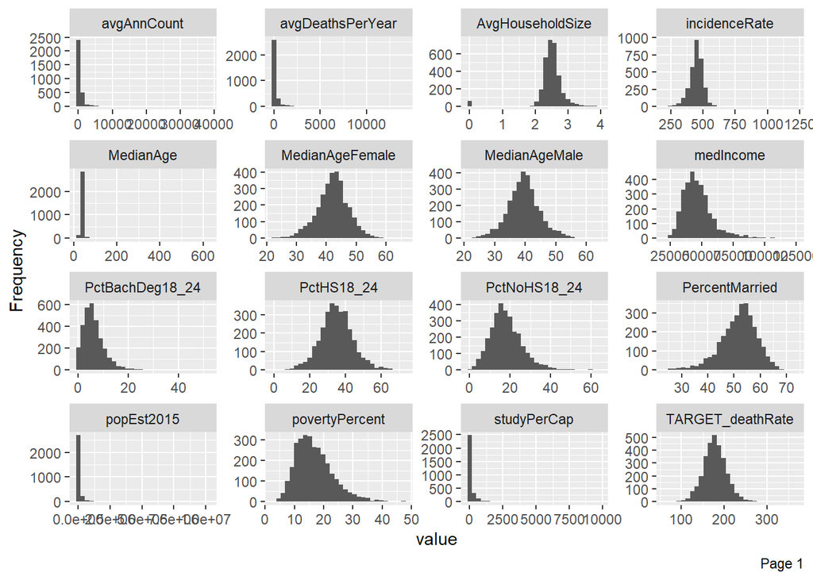

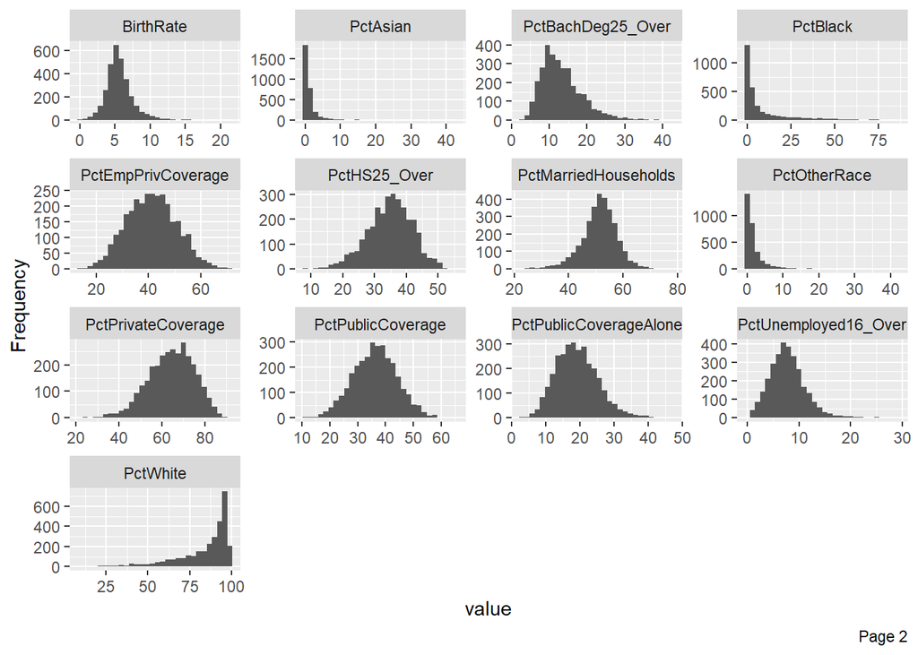

```r
plot_histogram(cancer1_cleaned)
```

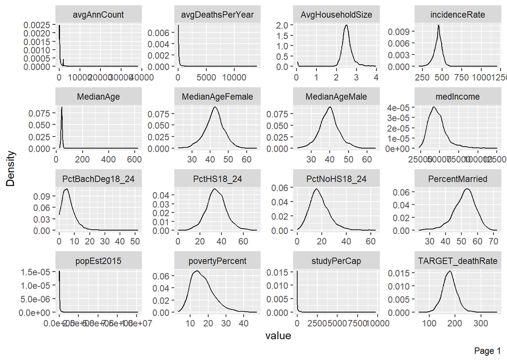

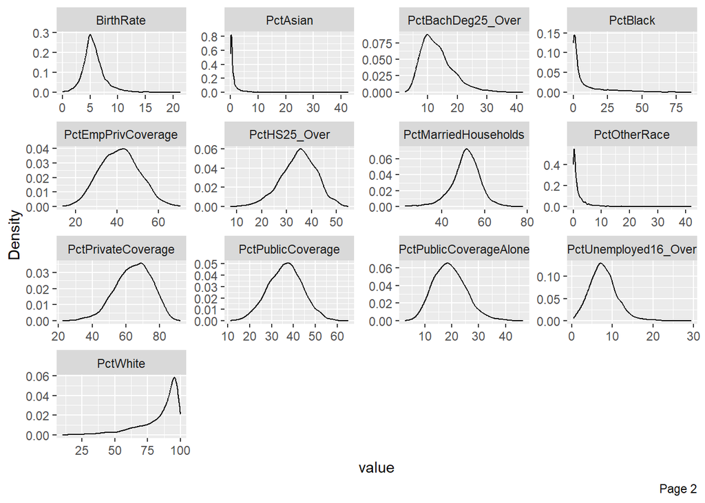

```r
plot_density(cancer1_cleaned)
```

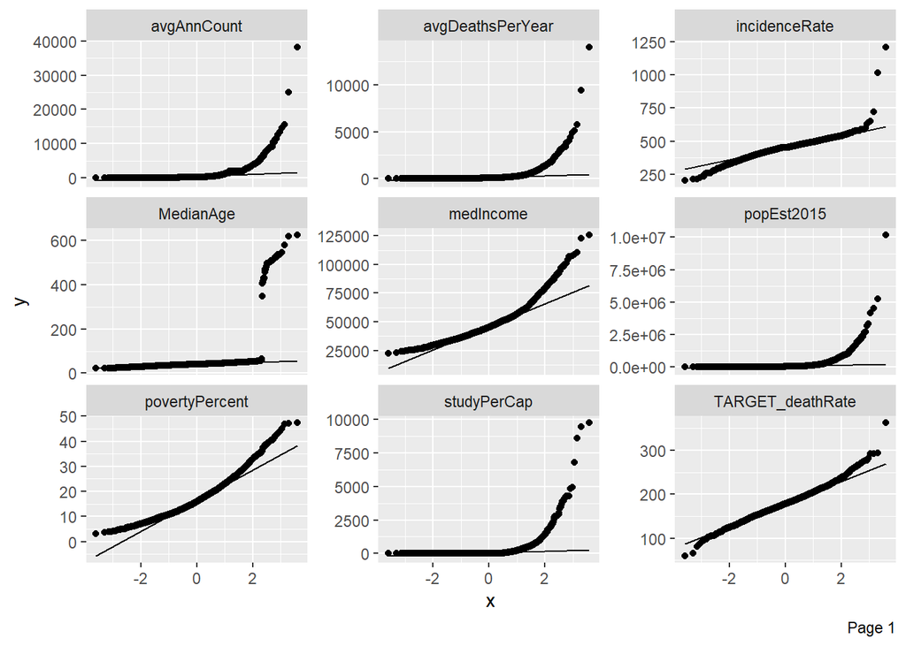

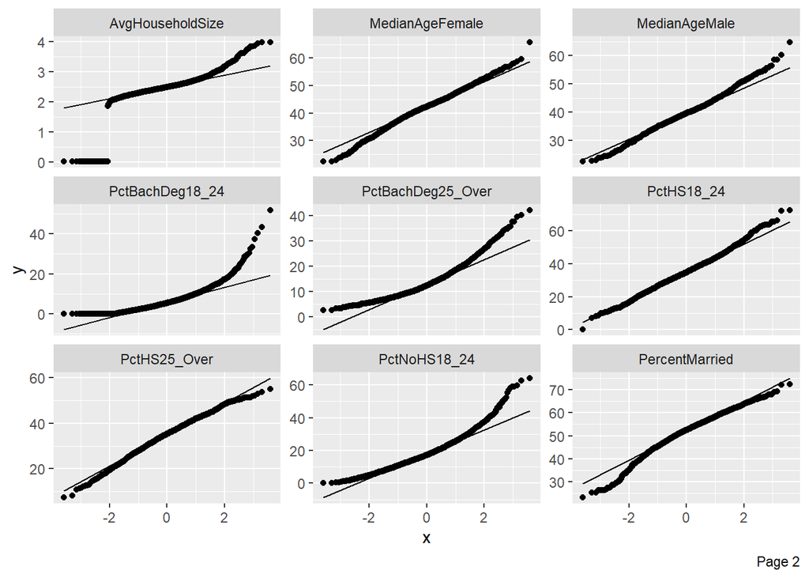

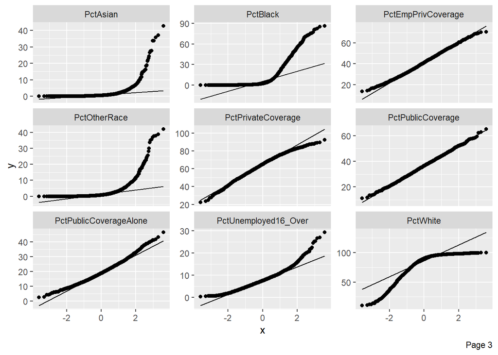

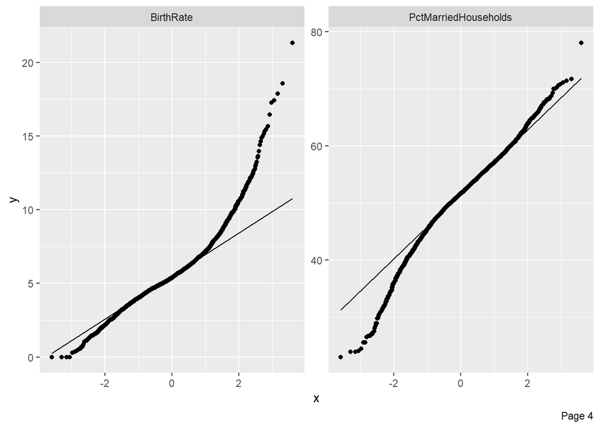

```r
plot_qq(cancer1_cleaned)
```

## Test for Normality

```r
ad.test(cancer1_cleaned$TARGET_deathRate)
```

```
##
##  Anderson-Darling normality test
##
## data:  cancer1_cleaned$TARGET_deathRate
## A = 4.0742, p-value = 3.908e-10
```

## Multiple regression analysis

```r
## Building a regression model
set.seed(123)
cancer1_cleaned_mixeddata <- cancer1_cleaned[order(runif(3047)),]
head(cancer1_cleaned_mixeddata, 5)
```

```
##      avgAnnCount avgDeathsPerYear TARGET_deathRate incidenceRate medIncome
## 478           22                8            125.9         424.9     40258
## 74           120               50            202.6         514.6     40013
## 1254          69               28            214.5         549.9     34073
## 740           71               35            229.6         461.4     34801
## 1181          49               19            147.8         412.7     51434
##      popEst2015 povertyPercent studyPerCap          binnedInc MedianAge
## 478        2759           13.0           0 (37413.8, 40362.7]      53.4
## 74        15816           18.5           0 (37413.8, 40362.7]      46.0
## 1254       9899           22.1           0   [22640, 34218.1]      41.1
## 740       11830           20.8           0 (34218.1, 37413.8]      44.3
## 1181       8585            9.7           0 (51046.4, 54545.6]      44.6
##      MedianAgeMale MedianAgeFemale                     Geography
## 478           51.4            56.4 McIntosh County, North Dakota
## 74            44.6            47.2  Wetzel County, West Virginia
```

[output cut: 27 more lines]

```r
# Select only numerical variables
cancer1_cleaned_mixeddata <- cancer1_cleaned_mixeddata[, sapply(cancer1_cleaned_mixeddata, is.numeric)]

# Split into 80:20 ratio
cancer1_training = cancer1_cleaned_mixeddata[1:2459,]
cancer1_testing = cancer1_cleaned_mixeddata[2460:3047,]

# Running the initial regression model
cancer1_lm_full <- lm(TARGET_deathRate~., data = cancer1_training)
summary(cancer1_lm_full)
```

```
##
## Call:
## lm(formula = TARGET_deathRate ~ ., data = cancer1_training)
##
## Residuals:
##     Min      1Q  Median      3Q     Max
## -95.888 -10.956  -0.698  10.635 134.245
##
## Coefficients:
##                          Estimate Std. Error t value Pr(>|t|)
## (Intercept)             1.345e+02  1.471e+01   9.142  < 2e-16 ***
## avgAnnCount            -3.556e-03  8.434e-04  -4.216 2.57e-05 ***
## avgDeathsPerYear        2.037e-02  4.521e-03   4.506 6.92e-06 ***
## incidenceRate           1.883e-01  8.412e-03  22.386  < 2e-16 ***
## medIncome               1.029e-04  9.132e-05   1.126  0.26007
## popEst2015             -1.768e-05  6.276e-06  -2.818  0.00488 **
## povertyPercent          5.395e-01  1.729e-01   3.121  0.00183 **
## studyPerCap            -4.504e-04  7.316e-04  -0.616  0.53814
## MedianAge              -1.472e-03  8.421e-03  -0.175  0.86126
## MedianAgeMale          -5.318e-01  2.320e-01  -2.292  0.02199 *
## MedianAgeFemale        -4.582e-02  2.428e-01  -0.189  0.85034
## AvgHouseholdSize        9.282e-01  1.078e+00   0.861  0.38948
## PercentMarried          8.819e-01  1.645e-01   5.361 9.08e-08 ***
## PctNoHS18_24           -1.607e-01  6.252e-02  -2.570  0.01024 *
## PctHS18_24              2.396e-01  5.525e-02   4.336 1.51e-05 ***
## PctBachDeg18_24        -1.816e-01  1.232e-01  -1.474  0.14069
## PctHS25_Over            3.229e-01  1.083e-01   2.980  0.00291 **
## PctBachDeg25_Over      -1.333e+00  1.723e-01  -7.738 1.47e-14 ***
## PctUnemployed16_Over    3.346e-01  1.797e-01   1.862  0.06274 .
## PctPrivateCoverage     -4.672e-01  1.455e-01  -3.211  0.00134 **
## PctEmpPrivCoverage      2.621e-01  1.126e-01   2.327  0.02003 *
## PctPublicCoverage       1.373e-01  2.426e-01   0.566  0.57164
## PctPublicCoverageAlone -1.192e-01  3.101e-01  -0.385  0.70063
## PctWhite               -6.225e-02  6.600e-02  -0.943  0.34562
## PctBlack                1.373e-02  6.406e-02   0.214  0.83034
## PctAsian                1.183e-01  2.107e-01   0.561  0.57455
## PctOtherRace           -8.884e-01  1.386e-01  -6.408 1.77e-10 ***
## PctMarriedHouseholds   -9.922e-01  1.581e-01  -6.275 4.14e-10 ***
## BirthRate              -9.161e-01  2.141e-01  -4.279 1.95e-05 ***
## ---
## Signif. codes:  0 '***' 0.001 '**' 0.01 '*' 0.05 '.' 0.1 ' ' 1
##
## Residual standard error: 19.49 on 2430 degrees of freedom
## Multiple R-squared:  0.5051, Adjusted R-squared:  0.4994
## F-statistic: 88.56 on 28 and 2430 DF,  p-value: < 2.2e-16
```

## Build reduced models

```r
le_step <- stepAIC(cancer1_lm_full,direction = "backward")
```

```
## Start:  AIC=14635.5
## TARGET_deathRate ~ avgAnnCount + avgDeathsPerYear + incidenceRate +
##     medIncome + popEst2015 + povertyPercent + studyPerCap + MedianAge +
##     MedianAgeMale + MedianAgeFemale + AvgHouseholdSize + PercentMarried +
##     PctNoHS18_24 + PctHS18_24 + PctBachDeg18_24 + PctHS25_Over +
##     PctBachDeg25_Over + PctUnemployed16_Over + PctPrivateCoverage +
##     PctEmpPrivCoverage + PctPublicCoverage + PctPublicCoverageAlone +
##     PctWhite + PctBlack + PctAsian + PctOtherRace + PctMarriedHouseholds +
##     BirthRate
##
##                          Df Sum of Sq     RSS   AIC
## - MedianAge               1        12  923333 14634
## - MedianAgeFemale         1        14  923335 14634
## - PctBlack                1        17  923339 14634
## - PctPublicCoverageAlone  1        56  923378 14634
## - PctAsian                1       120  923442 14634
## - PctPublicCoverage       1       122  923443 14634
## - studyPerCap             1       144  923466 14634
## - AvgHouseholdSize        1       281  923603 14634
## - PctWhite                1       338  923660 14634
## - medIncome               1       482  923804 14635
## <none>                                 923322 14636
## - PctBachDeg18_24         1       825  924147 14636
## - PctUnemployed16_Over    1      1317  924639 14637
## - MedianAgeMale           1      1996  925318 14639
## - PctEmpPrivCoverage      1      2058  925380 14639
## - PctNoHS18_24            1      2509  925831 14640
## - popEst2015              1      3017  926338 14642
## - PctHS25_Over            1      3375  926697 14642
## - povertyPercent          1      3700  927022 14643
## - PctPrivateCoverage      1      3917  927239 14644
## - avgAnnCount             1      6755  930077 14651
## - BirthRate               1      6956  930278 14652
## - PctHS18_24              1      7145  930467 14652
## - avgDeathsPerYear        1      7714  931036 14654
## - PercentMarried          1     10918  934240 14662
## - PctMarriedHouseholds    1     14959  938281 14673
## - PctOtherRace            1     15602  938924 14675
## - PctBachDeg25_Over       1     22752  946074 14693
## - incidenceRate           1    190417 1113738 15095
```

[output cut: 323 more lines]

```
## - PctHS25_Over          1      2787  927979 14626
## - popEst2015            1      2840  928033 14626
## - PctEmpPrivCoverage    1      3576  928768 14628
## - povertyPercent        1      3761  928954 14628
## - BirthRate             1      6614  931806 14636
## - avgAnnCount           1      6810  932003 14636
## - avgDeathsPerYear      1      7509  932701 14638
## - MedianAgeMale         1      7934  933126 14640
## - PctPrivateCoverage    1      8060  933252 14640
## - PctHS18_24            1      9359  934551 14643
## - PercentMarried        1      9990  935183 14645
## - PctMarriedHouseholds  1     14514  939706 14657
## - PctOtherRace          1     17443  942635 14664
## - PctBachDeg25_Over     1     28016  953209 14692
## - incidenceRate         1    198899 1124091 15097
```

```r
# Highest AIC
le1_lm_reduced1 = lm(TARGET_deathRate ~ avgAnnCount + avgDeathsPerYear + incidenceRate +
                       medIncome + popEst2015 + povertyPercent + studyPerCap + MedianAge +
                       MedianAgeMale + MedianAgeFemale + AvgHouseholdSize + PercentMarried +
                       PctNoHS18_24 + PctHS18_24 + PctBachDeg18_24 + PctHS25_Over +
                       PctBachDeg25_Over + PctUnemployed16_Over + PctPrivateCoverage +
                       PctEmpPrivCoverage + PctPublicCoverage + PctPublicCoverageAlone +
                       PctWhite + PctBlack + PctAsian + PctOtherRace + PctMarriedHouseholds +
                       BirthRate, data = cancer1_training)
summary(le1_lm_reduced1)
```

```
##
## Call:
## lm(formula = TARGET_deathRate ~ avgAnnCount + avgDeathsPerYear +
##     incidenceRate + medIncome + popEst2015 + povertyPercent +
##     studyPerCap + MedianAge + MedianAgeMale + MedianAgeFemale +
##     AvgHouseholdSize + PercentMarried + PctNoHS18_24 + PctHS18_24 +
##     PctBachDeg18_24 + PctHS25_Over + PctBachDeg25_Over + PctUnemployed16_Over +
##     PctPrivateCoverage + PctEmpPrivCoverage + PctPublicCoverage +
##     PctPublicCoverageAlone + PctWhite + PctBlack + PctAsian +
##     PctOtherRace + PctMarriedHouseholds + BirthRate, data = cancer1_training)
##
## Residuals:
##     Min      1Q  Median      3Q     Max
## -95.888 -10.956  -0.698  10.635 134.245
##
## Coefficients:
##                          Estimate Std. Error t value Pr(>|t|)
## (Intercept)             1.345e+02  1.471e+01   9.142  < 2e-16 ***
## avgAnnCount            -3.556e-03  8.434e-04  -4.216 2.57e-05 ***
## avgDeathsPerYear        2.037e-02  4.521e-03   4.506 6.92e-06 ***
## incidenceRate           1.883e-01  8.412e-03  22.386  < 2e-16 ***
## medIncome               1.029e-04  9.132e-05   1.126  0.26007
## popEst2015             -1.768e-05  6.276e-06  -2.818  0.00488 **
## povertyPercent          5.395e-01  1.729e-01   3.121  0.00183 **
## studyPerCap            -4.504e-04  7.316e-04  -0.616  0.53814
## MedianAge              -1.472e-03  8.421e-03  -0.175  0.86126
## MedianAgeMale          -5.318e-01  2.320e-01  -2.292  0.02199 *
## MedianAgeFemale        -4.582e-02  2.428e-01  -0.189  0.85034
## AvgHouseholdSize        9.282e-01  1.078e+00   0.861  0.38948
## PercentMarried          8.819e-01  1.645e-01   5.361 9.08e-08 ***
## PctNoHS18_24           -1.607e-01  6.252e-02  -2.570  0.01024 *
## PctHS18_24              2.396e-01  5.525e-02   4.336 1.51e-05 ***
## PctBachDeg18_24        -1.816e-01  1.232e-01  -1.474  0.14069
## PctHS25_Over            3.229e-01  1.083e-01   2.980  0.00291 **
## PctBachDeg25_Over      -1.333e+00  1.723e-01  -7.738 1.47e-14 ***
## PctUnemployed16_Over    3.346e-01  1.797e-01   1.862  0.06274 .
## PctPrivateCoverage     -4.672e-01  1.455e-01  -3.211  0.00134 **
## PctEmpPrivCoverage      2.621e-01  1.126e-01   2.327  0.02003 *
## PctPublicCoverage       1.373e-01  2.426e-01   0.566  0.57164
## PctPublicCoverageAlone -1.192e-01  3.101e-01  -0.385  0.70063
## PctWhite               -6.225e-02  6.600e-02  -0.943  0.34562
## PctBlack                1.373e-02  6.406e-02   0.214  0.83034
## PctAsian                1.183e-01  2.107e-01   0.561  0.57455
## PctOtherRace           -8.884e-01  1.386e-01  -6.408 1.77e-10 ***
## PctMarriedHouseholds   -9.922e-01  1.581e-01  -6.275 4.14e-10 ***
## BirthRate              -9.161e-01  2.141e-01  -4.279 1.95e-05 ***
## ---
## Signif. codes:  0 '***' 0.001 '**' 0.01 '*' 0.05 '.' 0.1 ' ' 1
##
## Residual standard error: 19.49 on 2430 degrees of freedom
## Multiple R-squared:  0.5051, Adjusted R-squared:  0.4994
## F-statistic: 88.56 on 28 and 2430 DF,  p-value: < 2.2e-16
```

```r
# Lowest AIC
le1_lm_reduced2 = lm(TARGET_deathRate ~ avgAnnCount + avgDeathsPerYear + incidenceRate +
                       popEst2015 + povertyPercent + MedianAgeMale + PercentMarried +
                       PctNoHS18_24 + PctHS18_24 + PctHS25_Over + PctBachDeg25_Over +
                       PctUnemployed16_Over + PctPrivateCoverage + PctEmpPrivCoverage +
                       PctWhite + PctOtherRace + PctMarriedHouseholds + BirthRate, data = cancer1_training)
summary(le1_lm_reduced2)
```

```
##
## Call:
## lm(formula = TARGET_deathRate ~ avgAnnCount + avgDeathsPerYear +
##     incidenceRate + popEst2015 + povertyPercent + MedianAgeMale +
##     PercentMarried + PctNoHS18_24 + PctHS18_24 + PctHS25_Over +
##     PctBachDeg25_Over + PctUnemployed16_Over + PctPrivateCoverage +
##     PctEmpPrivCoverage + PctWhite + PctOtherRace + PctMarriedHouseholds +
##     BirthRate, data = cancer1_training)
##
## Residuals:
##     Min      1Q  Median      3Q     Max
## -95.762 -10.954  -0.506  10.768 134.647
##
## Coefficients:
##                        Estimate Std. Error t value Pr(>|t|)
## (Intercept)           1.413e+02  1.224e+01  11.552  < 2e-16 ***
## avgAnnCount          -3.549e-03  8.375e-04  -4.238 2.34e-05 ***
## avgDeathsPerYear      1.993e-02  4.478e-03   4.450 8.97e-06 ***
## incidenceRate         1.888e-01  8.242e-03  22.903  < 2e-16 ***
## popEst2015           -1.688e-05  6.169e-06  -2.737  0.00625 **
## povertyPercent        4.537e-01  1.441e-01   3.150  0.00166 **
## MedianAgeMale        -5.219e-01  1.141e-01  -4.574 5.02e-06 ***
## PercentMarried        8.126e-01  1.583e-01   5.133 3.08e-07 ***
## PctNoHS18_24         -1.434e-01  5.974e-02  -2.400  0.01647 *
## PctHS18_24            2.635e-01  5.303e-02   4.968 7.23e-07 ***
## PctHS25_Over          2.835e-01  1.046e-01   2.711  0.00676 **
## PctBachDeg25_Over    -1.351e+00  1.572e-01  -8.596  < 2e-16 ***
## PctUnemployed16_Over  3.953e-01  1.718e-01   2.301  0.02146 *
## PctPrivateCoverage   -4.659e-01  1.011e-01  -4.611 4.22e-06 ***
## PctEmpPrivCoverage    2.766e-01  9.007e-02   3.071  0.00216 **
## PctWhite             -8.885e-02  3.663e-02  -2.426  0.01535 *
## PctOtherRace         -8.925e-01  1.316e-01  -6.782 1.48e-11 ***
## PctMarriedHouseholds -8.777e-01  1.419e-01  -6.187 7.17e-10 ***
## BirthRate            -8.852e-01  2.119e-01  -4.176 3.06e-05 ***
## ---
## Signif. codes:  0 '***' 0.001 '**' 0.01 '*' 0.05 '.' 0.1 ' ' 1
##
## Residual standard error: 19.47 on 2440 degrees of freedom
## Multiple R-squared:  0.5041, Adjusted R-squared:  0.5004
## F-statistic: 137.8 on 18 and 2440 DF,  p-value: < 2.2e-16
```

## Model Diagonostics

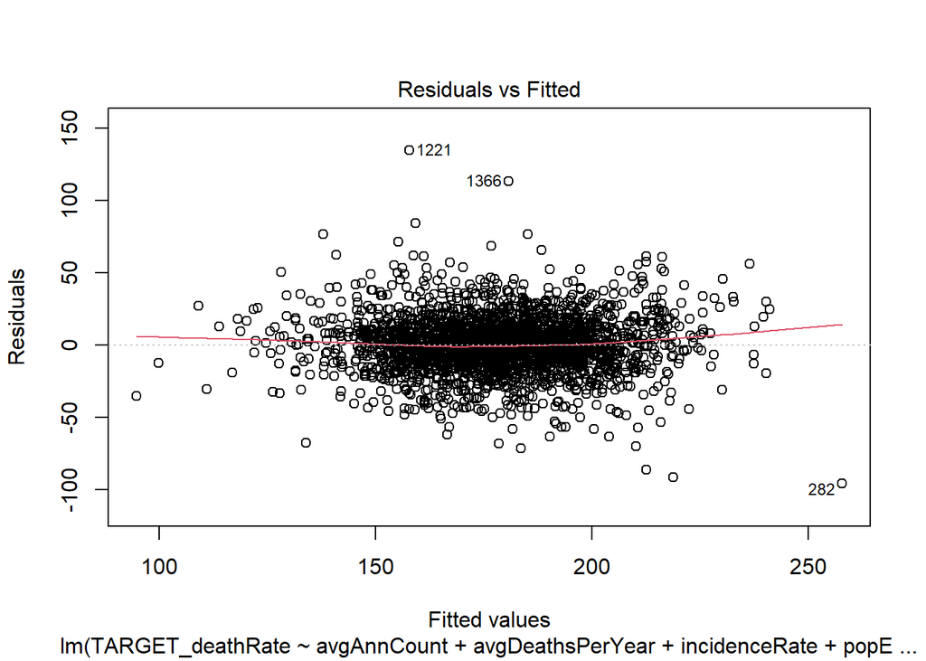

```r
# To check for linearity
plot(le1_lm_reduced2, which = 1)
```

Pattern and Spread: The residuals vs. fitted plot shows a random scatter of residuals around the horizontal axis, indicating no clear pattern, which suggests that the model’s assumptions about linearity and equal variance are reasonably met. However, the spread of residuals seems to be consistent across the range of fitted values, suggesting homoscedasticity.

Outliers and Influential Points: There are a few noticeable outliers and influential points (e.g., 1221, 1366, 282) that are far from the rest of the data, which could potentially affect the regression model’s accuracy and stability. These points should be examined further to understand their impact on the model.

```r
# To test for serial independence (autocorrelation) of errors
dwtest(le1_lm_reduced2)
```

```
##
##  Durbin-Watson test
##
## data:  le1_lm_reduced2
## DW = 2.0293, p-value = 0.7662
## alternative hypothesis: true autocorrelation is greater than 0
```

Test Statistic (DW = 2.0293): The Durbin-Watson statistic ranges from 0 to 4. A value around 2 suggests no autocorrelation. Values closer to 0 indicate positive autocorrelation, while values closer to 4 indicate negative autocorrelation. In this case, the DW value of 2.0293 is very close to 2, suggesting there is no significant autocorrelation in the residuals.

P-value (0.7662): The p-value indicates the probability of observing the test results under the null hypothesis that there is no autocorrelation. A high p-value (greater than 0.05) means we fail to reject the null hypothesis. In this case, with a p-value of 0.7662, we do not have sufficient evidence to suggest that there is autocorrelation in the residuals.

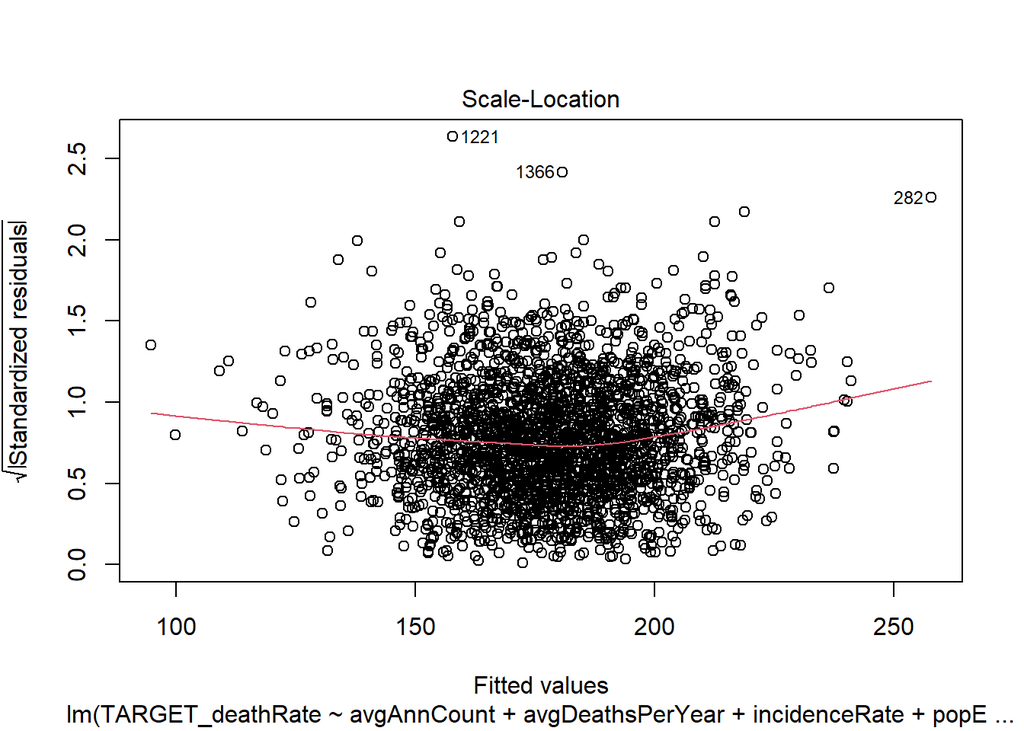

```r
# To detect heteroskedasticity (unequal variance of residuals)
plot(le1_lm_reduced2, which = 3)
```

Homoscedasticity: The scale-location plot shows the spread of the standardized residuals across the range of fitted values. The plot reveals a relatively consistent spread of residuals, indicating homoscedasticity. However, there is a slight upward trend in the red smoothing line, suggesting that variance may increase slightly with higher fitted values, which may indicate mild heteroscedasticity.

Outliers and Influential Points: Similar to the residuals vs. fitted plot, this plot also highlights a few influential points (e.g., 1221, 1366, 282) that are further away from the bulk of the data. These points should be further investigated to understand their influence on the regression model.

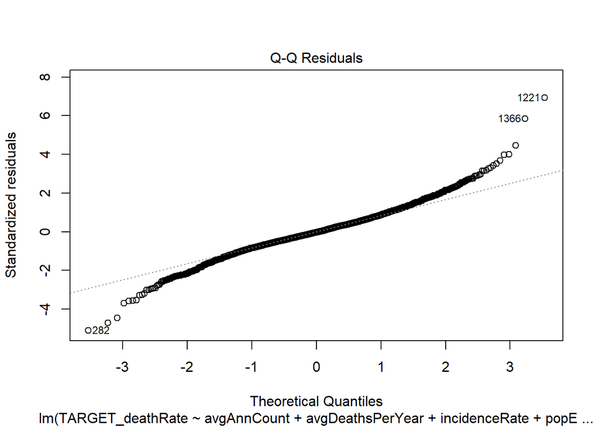

```r
# To check the normality assumption of residuals
plot(le1_lm_reduced2, which = 2)
```

Normality of Residuals: The Q-Q plot shows the standardized residuals plotted against the theoretical quantiles from a standard normal distribution. The majority of the residuals follow the 45-degree reference line, indicating that the residuals are approximately normally distributed. However, there are deviations at the tails, with some points (e.g., 1221, 1366, 282) deviating significantly from the line, suggesting potential issues with normality in the extreme values.

Outliers and Extreme Values: The points labeled 1221, 1366, and 282 are noticeable outliers as they deviate significantly from the reference line, indicating that these observations have unusually large residuals compared to the others. These outliers might affect the assumptions of the regression model and should be investigated further to understand their impact.

```r
# To assess multicollinearity (high correlation among predictor variables)
vif(le1_lm_reduced2)
```

```
##          avgAnnCount     avgDeathsPerYear        incidenceRate
##             9.797306            35.313276             1.233539
##           popEst2015       povertyPercent        MedianAgeMale
##            29.935033             5.405017             2.271899
##       PercentMarried         PctNoHS18_24           PctHS18_24
##             7.445757             1.517444             1.480192
##         PctHS25_Over    PctBachDeg25_Over PctUnemployed16_Over
##             3.482583             4.629721             2.220946
##   PctPrivateCoverage   PctEmpPrivCoverage             PctWhite
##             7.429115             4.665317             2.253894
##         PctOtherRace PctMarriedHouseholds            BirthRate
##             1.423382             5.420063             1.168479
```

Variables such as avgDeathsPerYear and popEst2015 have very high VIF values, indicating strong multicollinearity. It might be necessary to consider removing or combining these variables, or using techniques like Principal Component Analysis (PCA) or Ridge Regression to address multicollinearity in the model. Variables with moderate to high VIF values should also be closely examined to ensure they do not unduly influence the regression model.